# Telco Customer Churn

# Background, the business context

In this challange the goal is to predict behavior of customers to retain them.

Telephone service companies, Internet service providers, pay TV companies, insurance firms, and alarm monitoring services, often use customer attrition analysis and customer attrition rates as one of their key business metrics because the cost of retaining an existing customer is far less than acquiring a new one. Companies from these sectors often have customer service branches which attempt to win back defecting clients, because recovered long-term customers can be worth much more to a company than newly recruited clients.

Predictive analytics use churn prediction models that predict customer churn by assessing their propensity of risk to churn. Since these models generate a small prioritized list of potential defectors, they are effective at focusing customer retention marketing programs on the subset of the customer base who are most vulnerable to churn.

# Load some packeages

```r
library(data.table)
library(ggplot2)
library(caret)
```

# Read in the data

```r
data <- fread(input = "D:/teaching/telco_customer_churn/data.csv")
```

Inspect it:

```r
head(data)
```

| customerID | gender | SeniorCitizen | Partner | Dependents | tenure | PhoneService | MultipleLines | InternetService | OnlineSecurity | OnlineBackup | DeviceProtection | TechSupport | StreamingTV | StreamingMovies | Contract | PaperlessBilling | PaymentMethod | MonthlyCharges | TotalCharges | Churn |
| --- | --- | --- | --- | --- | --- | --- | --- | --- | --- | --- | --- | --- | --- | --- | --- | --- | --- | --- | --- | --- |
| 7590-VHVEG | Female | 0 | Yes | No | 1 | No | No phone service | DSL | No | Yes | No | No | No | No | Month-to-month | Yes | Electronic check | 29.85 | 29.85 | No |
| 5575-GNVDE | Male | 0 | No | No | 34 | Yes | No | DSL | Yes | No | Yes | No | No | No | One year | No | Mailed check | 56.95 | 1889.50 | No |
| 3668-QPYBK | Male | 0 | No | No | 2 | Yes | No | DSL | Yes | Yes | No | No | No | No | Month-to-month | Yes | Mailed check | 53.85 | 108.15 | Yes |
| 7795-CFOCW | Male | 0 | No | No | 45 | No | No phone service | DSL | Yes | No | Yes | Yes | No | No | One year | No | Bank transfer (automatic) | 42.30 | 1840.75 | No |
| 9237-HQITU | Female | 0 | No | No | 2 | Yes | No | Fiber optic | No | No | No | No | No | No | Month-to-month | Yes | Electronic check | 70.70 | 151.65 | Yes |
| 9305-CDSKC | Female | 0 | No | No | 8 | Yes | Yes | Fiber optic | No | No | Yes | No | Yes | Yes | Month-to-month | Yes | Electronic check | 99.65 | 820.50 | Yes |

This is a very clean dataset in real life probably you are not going to meet data like this. But for demonstration this is ideal.

```r
data[, customerID:= NULL] #drop cutomerID
```

# Understand what we have

Each row represents a customer, each column contains customer’s attributes described on the column Metadata.

The data set includes information about:

- Customers who left within the last month – the column is called Churn
- Services that each customer has signed up for – phone, multiple lines, internet, online security, online backup, device protection, tech support, and streaming TV and movies
- Customer account information – how long they’ve been a customer, contract, payment method, paperless billing, monthly charges, and total charges
- Demographic info about customers – gender, age range, and if they have partners and dependents

# EDA - Exploratory Data Analysis

### Observation number:

In other words: how many lines do we have?

```r
nrow(data)
```

```
## [1] 7043
```

We have data for 7043 customers.

Lets look at some of the variables.

## Missing values

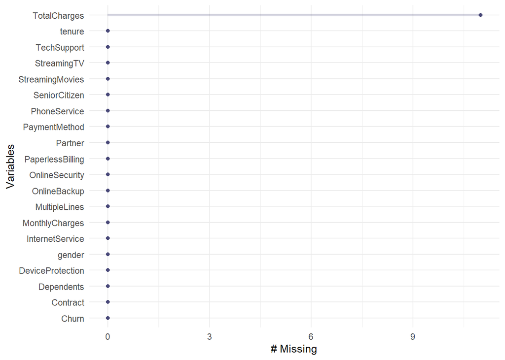

```r
#install.packages("naniar")
#install.packages("VIM")
library(naniar)
gg_miss_var(data)
```

We can see that we have missing values in the ‘TotalCharges’ columns. Lets look at them, we might figure out why they are missing.

```r
sum(is.na(data$TotalCharges))
```

```
## [1] 11
```

```r
data[is.na(TotalCharges)]
```

| gender | SeniorCitizen | Partner | Dependents | tenure | PhoneService | MultipleLines | InternetService | OnlineSecurity | OnlineBackup | DeviceProtection | TechSupport | StreamingTV | StreamingMovies | Contract | PaperlessBilling | PaymentMethod | MonthlyCharges | TotalCharges | Churn |
| --- | --- | --- | --- | --- | --- | --- | --- | --- | --- | --- | --- | --- | --- | --- | --- | --- | --- | --- | --- |
| Female | 0 | Yes | Yes | 0 | No | No phone service | DSL | Yes | No | Yes | Yes | Yes | No | Two year | Yes | Bank transfer (automatic) | 52.55 | NA | No |
| Male | 0 | No | Yes | 0 | Yes | No | No | No internet service | No internet service | No internet service | No internet service | No internet service | No internet service | Two year | No | Mailed check | 20.25 | NA | No |
| Female | 0 | Yes | Yes | 0 | Yes | No | DSL | Yes | Yes | Yes | No | Yes | Yes | Two year | No | Mailed check | 80.85 | NA | No |
| Male | 0 | Yes | Yes | 0 | Yes | Yes | No | No internet service | No internet service | No internet service | No internet service | No internet service | No internet service | Two year | No | Mailed check | 25.75 | NA | No |
| Female | 0 | Yes | Yes | 0 | No | No phone service | DSL | Yes | Yes | Yes | Yes | Yes | No | Two year | No | Credit card (automatic) | 56.05 | NA | No |
| Male | 0 | Yes | Yes | 0 | Yes | No | No | No internet service | No internet service | No internet service | No internet service | No internet service | No internet service | Two year | No | Mailed check | 19.85 | NA | No |
| Male | 0 | Yes | Yes | 0 | Yes | Yes | No | No internet service | No internet service | No internet service | No internet service | No internet service | No internet service | Two year | No | Mailed check | 25.35 | NA | No |
| Female | 0 | Yes | Yes | 0 | Yes | No | No | No internet service | No internet service | No internet service | No internet service | No internet service | No internet service | Two year | No | Mailed check | 20.00 | NA | No |
| Male | 0 | Yes | Yes | 0 | Yes | No | No | No internet service | No internet service | No internet service | No internet service | No internet service | No internet service | One year | Yes | Mailed check | 19.70 | NA | No |
| Female | 0 | Yes | Yes | 0 | Yes | Yes | DSL | No | Yes | Yes | Yes | Yes | No | Two year | No | Mailed check | 73.35 | NA | No |

[output cut: 1 more lines]

I cannot realy tell why they are missing. One of the reason can be that they have not been charged yet, they are in their first month of their contract.

I replace the missing values with the median of the ‘TotalCharges’.

```r
medianTotalCharges <- round(median(data$TotalCharges, na.rm = T))
medianTotalCharges
```

```
## [1] 1397
```

```r
data[is.na(TotalCharges), TotalCharges:= medianTotalCharges]
```

```r
sum(is.na(data))
```

```
## [1] 0
```

## Variables:

### Churn:

This is the variable that we would like to predict. We would like to have a model which takes all the other variables and tells us whether a given person is going to churn in the next month or not, and the probability of this.

How many and what is the prectiage of people who churned?

```r
countingTable <- data[, .(N = .N), by = Churn]
countingTable[, all:= sum(N, na.rm = T)]
countingTable[, proportions:= N/all]
countingTable[, proportions:= round(proportions, digits = 3)]
countingTable
```

| Churn | N | all | proportions |
| --- | --- | --- | --- |
| No | 5174 | 7043 | 0.735 |
| Yes | 1869 | 7043 | 0.265 |

We can see that 27% of the customers in our data churned.

We can plot this as well:

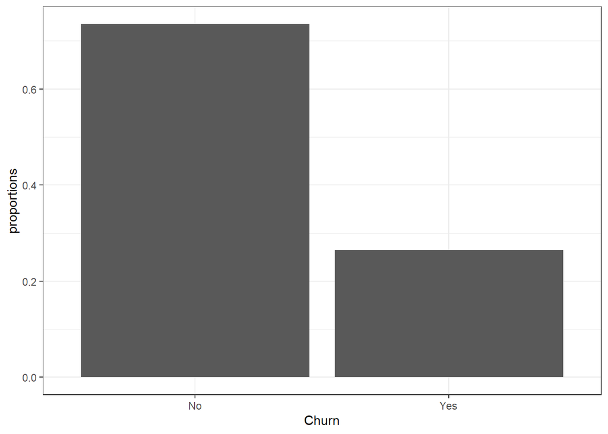

```r
ggplot(countingTable, aes(x = Churn, y = proportions)) +
  geom_bar(stat = "identity") +
  theme_bw()
```

We can see that this is an unbalanced dataset, but not that much. It is useful to know how unbalanced our data for choosing the right workflow, alorithm and evaluation method, etc.

Also, I am creating a new variable called ‘churnNumeric’ based on our ‘Churn’ variable based on this rule:

- If ‘Churn’ is ‘Yes’ I am assigning 1 to it
- If ‘Churn’ is ‘No’ I am assingin 0 to it

It will come handy later.

```r
data[, churnNumeric:= ifelse(Churn == "Yes", 1, 0)]
```

## Gender

```r
countingTableGender <- data[, .(N = .N), by = gender]
countingTableGender[, all:= sum(N, na.rm = T)]
countingTableGender[, proportions:= N/all]
countingTableGender[, proportions:= round(proportions, digits = 3)]
countingTableGender
```

| gender | N | all | proportions |
| --- | --- | --- | --- |
| Female | 3488 | 7043 | 0.495 |
| Male | 3555 | 7043 | 0.505 |

Equal amount of males and females.

### Does gender has an influence on Churn?

To see this we can calculate the proportions of churn by gender:

```r
countingTableGenderProportions <- data[, .N, by = .(gender, Churn)]
countingTableGenderProportions[, allByGender:= sum(N, na.rm = T), by = gender]
countingTableGenderProportions[, proportions:=N/allByGender]
countingTableGenderProportions[, proportions:=round(proportions, digits = 3)]
countingTableGenderProportions
```

| gender | Churn | N | allByGender | proportions |
| --- | --- | --- | --- | --- |
| Female | No | 2549 | 3488 | 0.731 |
| Male | No | 2625 | 3555 | 0.738 |
| Male | Yes | 930 | 3555 | 0.262 |
| Female | Yes | 939 | 3488 | 0.269 |

Almost the same proportion of males and fames churned: 26.2% vs 26.9%. It seems like gender is not an important variable when it comes to churn.

## MonthlyCharges

```r
summary(data$MonthlyCharges)
```

```
##    Min. 1st Qu.  Median    Mean 3rd Qu.    Max.
##   18.25   35.50   70.35   64.76   89.85  118.75
```

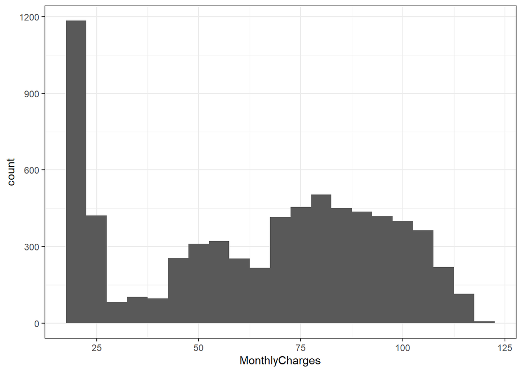

```r
ggplot(data, aes(MonthlyCharges)) +
  geom_histogram(binwidth = 5) +
  theme_bw()
```

We can calculate the proportions of Churn by ‘MonthlyCharges’ groups. What do we need for that one?

Groups.

So lets create groups first. We can do that in many ways, but for now I will do it manualy wtih arbitrary values:

- If ‘MonthlyCharges’ < 25 then 1
- If 25 <= ‘MonthlyCharges’ < 50 then 2
- If 50 <= ‘MonthlyCharges’ < 75 then 3
- If 75 <= ‘MonthlyCharges’ < 100 then 4
- If 100 <= ‘MonthlyCharges’ then 5

I am ending up with 5 groups.

```r
data[, MonthlyChargesGroup:= cut(as.numeric(MonthlyCharges),
                                 breaks = c(min(MonthlyCharges - 1), 25, 50, 75, 100, max(MonthlyCharges + 1)),
                                 labels = c(1, 2, 3, 4, 5),
                                 right = F)]
```

```r
table(data$MonthlyCharges, data$MonthlyChargesGroup)[75:100, ]
```

```
##
##          1  2  3  4  5
##   24.1   8  0  0  0  0
##   24.15  6  0  0  0  0
##   24.2   5  0  0  0  0
##   24.25 10  0  0  0  0
##   24.3   7  0  0  0  0
##   24.35  6  0  0  0  0
##   24.4  11  0  0  0  0
##   24.45 15  0  0  0  0
##   24.5   7  0  0  0  0
##   24.55  6  0  0  0  0
##   24.6   9  0  0  0  0
##   24.65  8  0  0  0  0
##   24.7  12  0  0  0  0
##   24.75 10  0  0  0  0
##   24.8  15  0  0  0  0
##   24.85 10  0  0  0  0
##   24.9  11  0  0  0  0
##   24.95 12  0  0  0  0
##   25     0 17  0  0  0
##   25.05  0 14  0  0  0
##   25.1   0 19  0  0  0
##   25.15  0 14  0  0  0
##   25.2   0 10  0  0  0
##   25.25  0 20  0  0  0
##   25.3   0 10  0  0  0
##   25.35  0  6  0  0  0
```

```r
data$MonthlyChargesGroup <- as.numeric(data$MonthlyChargesGroup)
data$MonthlyCharges <- as.numeric(data$MonthlyCharges)
```

Now we have groups. We can calculate the proportion of churn in each group. Now our binary (1/0) variable - ‘churnNumeric’ - what we created before based on the ‘Churn’ variables is hand. Because we can take the mean of them within each group and that will give us the proportion of churn.

```r
meanChurnByGroup <- data[order(MonthlyChargesGroup), .(meanChurn = mean(churnNumeric, na.rm = T)), by = MonthlyChargesGroup]
meanChurnByGroup
```

| MonthlyChargesGroup | meanChurn |
| --- | --- |
| 1 | 0.09143269 |
| 2 | 0.25856354 |
| 3 | 0.26156693 |
| 4 | 0.37252252 |
| 5 | 0.28303965 |

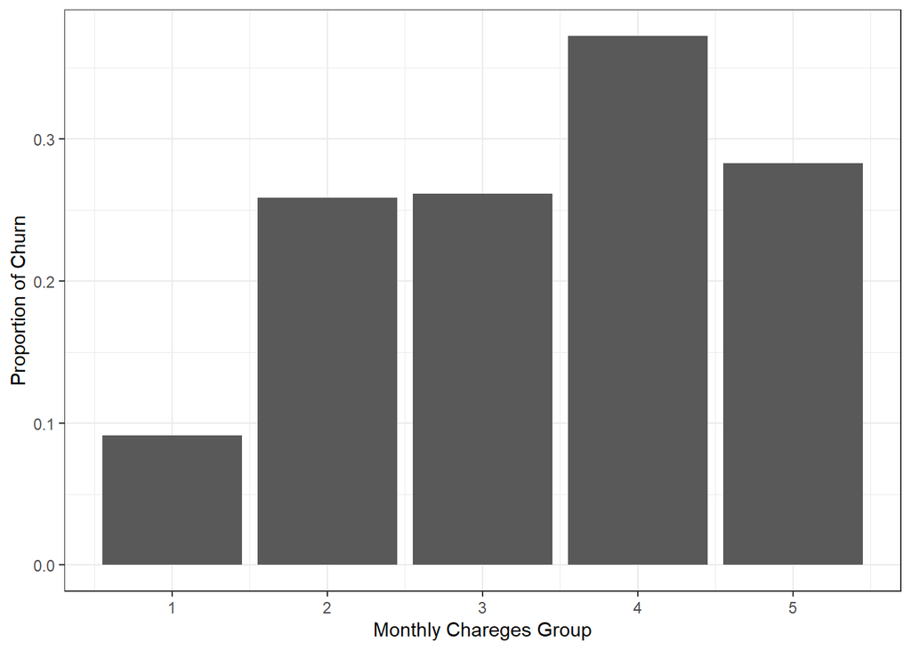

```r
ggplot(meanChurnByGroup, aes(x = MonthlyChargesGroup, y = meanChurn)) +
  geom_bar(stat = "identity") +
  labs(x = "Monthly Chareges Group", y = "Proportion of Churn") +
  theme_bw()
```

## Doing it for all the varialbe is tedious

Now, as you get the concept you can to the same for every variable manualy to get familiar with your data. Maybe createing a fucktion is handy and saves you a lot of work.

OR

You can use packages which simplyfies your work. I will show you some example here:

```r
#install.packages("SmartEDA")
library(SmartEDA)
```

```r
ExpData(data=data,type=1)
```

| Descriptions | Value |
| --- | --- |
| Sample size (nrow) | 7043 |
| No. of variables (ncol) | 22 |
| No. of numeric/interger variables | 6 |
| No. of factor variables | 0 |
| No. of text variables | 16 |
| No. of logical variables | 0 |
| No. of identifier variables | 0 |
| No. of date variables | 0 |
| No. of zero variance variables (uniform) | 0 |
| %. of variables having complete cases | 100% (22) |

[output cut: 3 more lines]

```r
ExpData(data=data, type=2)
```

| Index | Variable_Name | Variable_Type | Per_of_Missing | No_of_distinct_values |
| --- | --- | --- | --- | --- |
| 1 | gender | character | 0 | 2 |
| 2 | SeniorCitizen | integer | 0 | 2 |
| 3 | Partner | character | 0 | 2 |
| 4 | Dependents | character | 0 | 2 |
| 5 | tenure | integer | 0 | 73 |
| 6 | PhoneService | character | 0 | 2 |
| 7 | MultipleLines | character | 0 | 3 |
| 8 | InternetService | character | 0 | 3 |
| 9 | OnlineSecurity | character | 0 | 3 |
| 10 | OnlineBackup | character | 0 | 3 |

[output cut: 12 more lines]

```r
ExpNumStat(data, by="A", gp=NULL,  Qnt = seq(0,1, 0.2), MesofShape = 2, Outlier = TRUE, round = 2)
```

|  | Vname | Group | TN | nNeg | nZero | nPos | NegInf | PosInf | NA_Value | Per_of_Missing | sum | min | max | mean | median | SD | CV | IQR | Skewness | Kurtosis | 0% | 20% | 40% | 60% | 80% | 100% | LB.25% | UB.75% | nOutliers |
| --- | --- | --- | --- | --- | --- | --- | --- | --- | --- | --- | --- | --- | --- | --- | --- | --- | --- | --- | --- | --- | --- | --- | --- | --- | --- | --- | --- | --- | --- |
| 2 | MonthlyCharges | All | 7043 | 0 | 0 | 7043 | 0 | 0 | 0 | 0 | 456116.6 | 18.25 | 118.75 | 64.76 | 70.35 | 30.09 | 0.46 | 54.35 | -0.22 | -1.26 | 18.25 | 25.05 | 58.83 | 79.10 | 94.25 | 118.75 | -46.02 | 171.38 | 0 |
| 1 | tenure | All | 7043 | 0 | 11 | 7032 | 0 | 0 | 0 | 0 | 227990.0 | 0.00 | 72.00 | 32.37 | 29.00 | 24.56 | 0.76 | 46.00 | 0.24 | -1.39 | 0.00 | 6.00 | 20.00 | 40.00 | 60.00 | 72.00 | -60.00 | 124.00 | 0 |
| 3 | TotalCharges | All | 7043 | 0 | 0 | 7043 | 0 | 0 | 0 | 0 | 16071535.7 | 18.80 | 8684.80 | 2281.92 | 1397.00 | 2265.27 | 0.99 | 3384.38 | 0.96 | -0.23 | 18.80 | 267.37 | 947.38 | 2043.71 | 4471.44 | 8684.80 | -4674.34 | 8863.16 | 0 |

```r
ExpNumStat(data, by="G", gp="Churn",  Qnt = seq(0,1, 0.2), MesofShape = 2, Outlier = TRUE, round = 2)
```

|  | Vname | Group | TN | nNeg | nZero | nPos | NegInf | PosInf | NA_Value | Per_of_Missing | sum | min | max | mean | median | SD | CV | IQR | Skewness | Kurtosis | 0% | 20% | 40% | 60% | 80% | 100% | LB.25% | UB.75% | nOutliers |
| --- | --- | --- | --- | --- | --- | --- | --- | --- | --- | --- | --- | --- | --- | --- | --- | --- | --- | --- | --- | --- | --- | --- | --- | --- | --- | --- | --- | --- | --- |
| 2 | MonthlyCharges | Churn:No | 5174 | 0 | 0 | 5174 | 0 | 0 | 0 | 0 | 316985.8 | 18.25 | 118.75 | 61.27 | 64.43 | 31.09 | 0.51 | 63.30 | -0.03 | -1.36 | 18.25 | 20.85 | 53.50 | 74.70 | 92.00 | 118.75 | -69.85 | 183.35 | 0 |
| 5 | MonthlyCharges | Churn:Yes | 1869 | 0 | 0 | 1869 | 0 | 0 | 0 | 0 | 139130.9 | 18.85 | 118.35 | 74.44 | 79.65 | 24.67 | 0.33 | 38.05 | -0.73 | -0.36 | 18.85 | 50.45 | 74.50 | 84.94 | 95.94 | 118.35 | -0.93 | 151.28 | 0 |
| 1 | tenure | Churn:No | 5174 | 0 | 11 | 5163 | 0 | 0 | 0 | 0 | 194387.0 | 0.00 | 72.00 | 37.57 | 38.00 | 24.11 | 0.64 | 46.00 | -0.03 | -1.41 | 0.00 | 11.00 | 28.00 | 48.00 | 65.00 | 72.00 | -54.00 | 130.00 | 0 |
| 4 | tenure | Churn:Yes | 1869 | 0 | 0 | 1869 | 0 | 0 | 0 | 0 | 33603.0 | 1.00 | 72.00 | 17.98 | 10.00 | 19.53 | 1.09 | 27.00 | 1.15 | 0.19 | 1.00 | 1.00 | 6.00 | 15.00 | 35.00 | 72.00 | -38.50 | 69.50 | 23 |
| 3 | TotalCharges | Churn:No | 5174 | 0 | 0 | 5174 | 0 | 0 | 0 | 0 | 13208608.8 | 18.80 | 8672.45 | 2552.88 | 1679.53 | 2327.59 | 0.91 | 3683.27 | 0.81 | -0.55 | 18.80 | 419.82 | 1215.68 | 2496.80 | 4890.90 | 8672.45 | -4945.34 | 9787.76 | 0 |
| 6 | TotalCharges | Churn:Yes | 1869 | 0 | 0 | 1869 | 0 | 0 | 0 | 0 | 2862926.9 | 18.85 | 8684.80 | 1531.80 | 703.55 | 1890.82 | 1.23 | 2196.80 | 1.51 | 1.46 | 18.85 | 85.03 | 371.70 | 1128.75 | 2840.41 | 8684.80 | -3160.70 | 5626.50 | 109 |

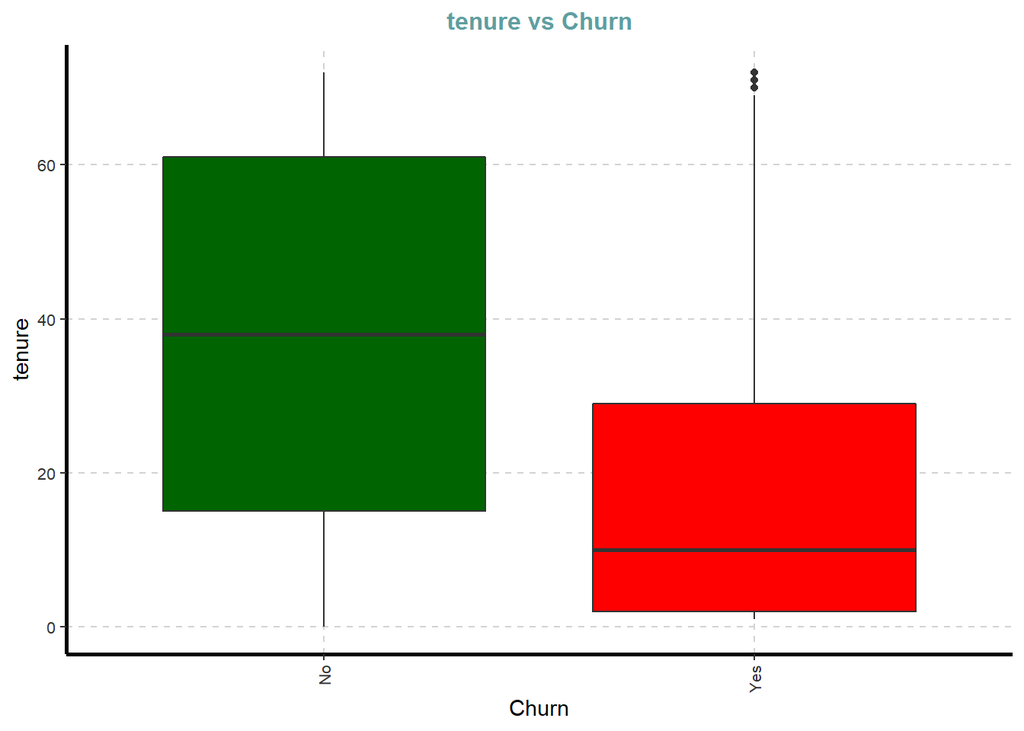

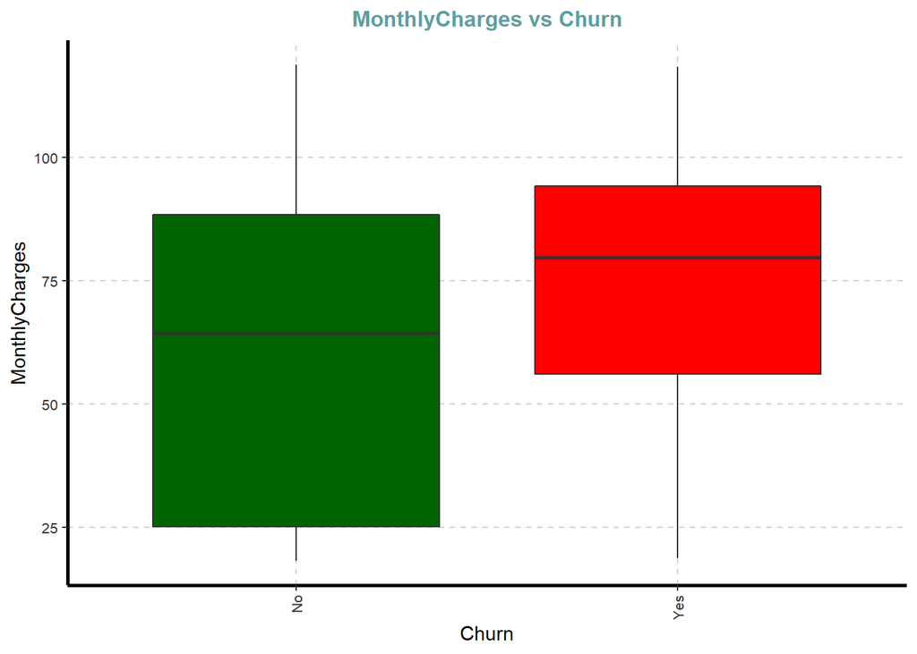

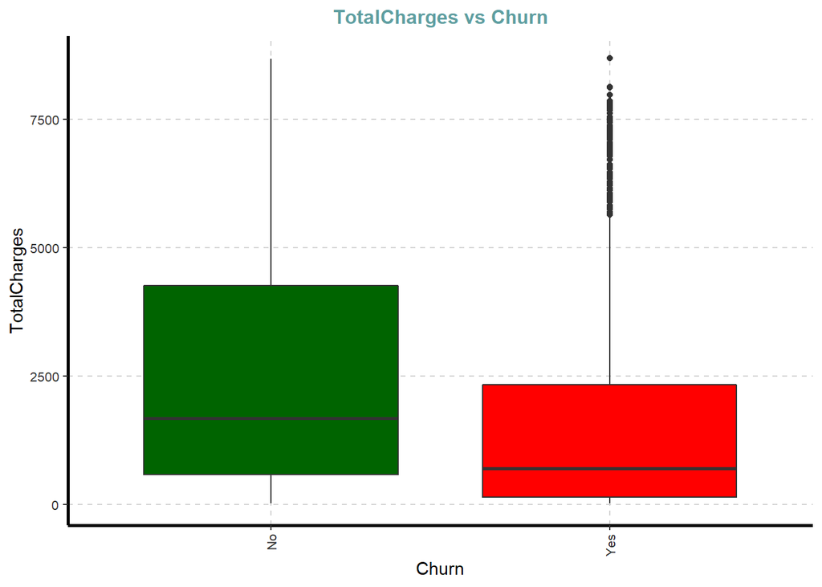

```r
ExpNumViz(data, target="Churn", type = 2, nlim = 25, col = c("DarkGreen", "Red"))
```

```r
ExpCTable(data, Target="Churn", margin=1, clim=10, nlim=5, round=2, bin=NULL, per=TRUE)
```

| VARIABLE | CATEGORY | Number | Churn:No | Churn:Yes | TOTAL |
| --- | --- | --- | --- | --- | --- |
| gender | Female | nn | 2549.00 | 939.00 | 3488.00 |
| gender | Male | nn | 2625.00 | 930.00 | 3555.00 |
| gender | TOTAL | nn | 5174.00 | 1869.00 | 7043.00 |
| gender | Female | % | 49.27 | 50.24 | 49.52 |
| gender | Male | % | 50.73 | 49.76 | 50.48 |
| gender | TOTAL | % | 100.00 | 100.00 | 100.00 |
| Partner | No | nn | 2441.00 | 1200.00 | 3641.00 |
| Partner | Yes | nn | 2733.00 | 669.00 | 3402.00 |
| Partner | TOTAL | nn | 5174.00 | 1869.00 | 7043.00 |
| Partner | No | % | 47.18 | 64.21 | 51.70 |

[output cut: 126 more lines]

```r
ExpCatStat(data ,Target="Churn",result = "Stat", clim=10, nlim=5, Pclass="Yes")
```

| Variable | Target | Unique | Chi-squared | p-value | df | IV Value | Cramers V | Degree of Association | Predictive Power |
| --- | --- | --- | --- | --- | --- | --- | --- | --- | --- |
| gender | Churn | 2 | 0.484 | 0.487 | 1 | 0.00 | 0.01 | Very Weak | Not Predictive |
| Partner | Churn | 2 | 158.733 | 0.000 | 1 | 0.12 | 0.15 | Weak | Somewhat Predictive |
| Dependents | Churn | 2 | 189.129 | 0.000 | 1 | 0.16 | 0.16 | Weak | Somewhat Predictive |
| PhoneService | Churn | 2 | 0.915 | 0.339 | 1 | 0.00 | 0.01 | Very Weak | Not Predictive |
| MultipleLines | Churn | 3 | 11.330 | 0.003 | 2 | 0.00 | 0.04 | Very Weak | Not Predictive |
| InternetService | Churn | 3 | 732.310 | 0.000 | 2 | 0.60 | 0.32 | Strong | Highly Predictive |
| OnlineSecurity | Churn | 3 | 849.999 | 0.000 | 2 | 0.71 | 0.35 | Strong | Highly Predictive |
| OnlineBackup | Churn | 3 | 601.813 | 0.000 | 2 | 0.52 | 0.29 | Moderate | Highly Predictive |
| DeviceProtection | Churn | 3 | 558.419 | 0.000 | 2 | 0.50 | 0.28 | Moderate | Highly Predictive |
| TechSupport | Churn | 3 | 828.197 | 0.000 | 2 | 0.70 | 0.34 | Strong | Highly Predictive |

[output cut: 11 more lines]

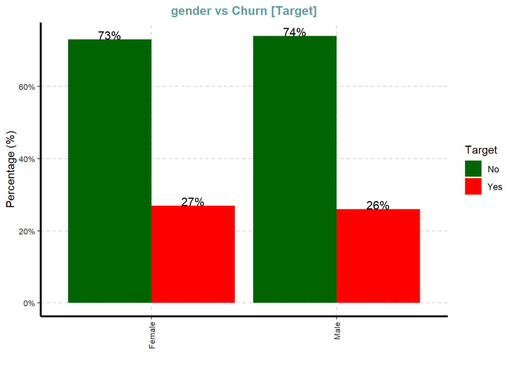

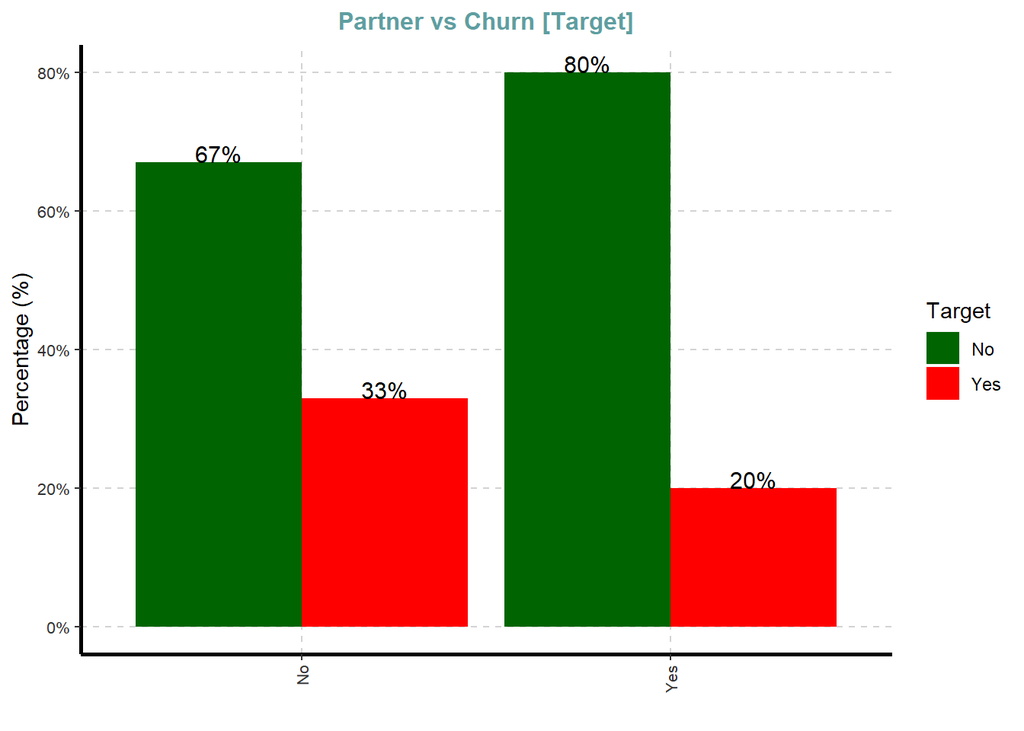

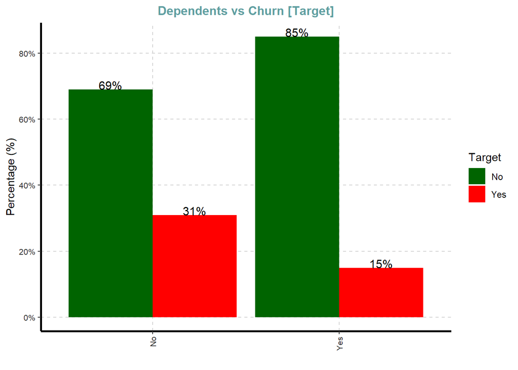

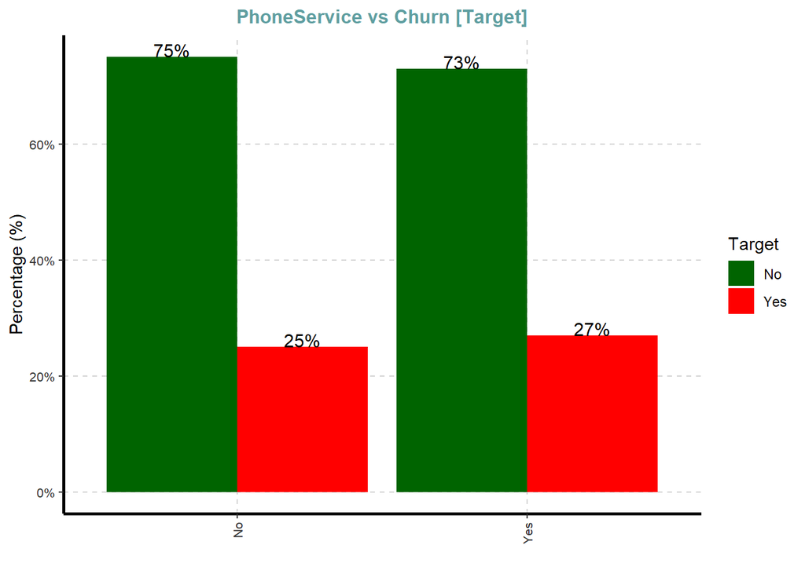

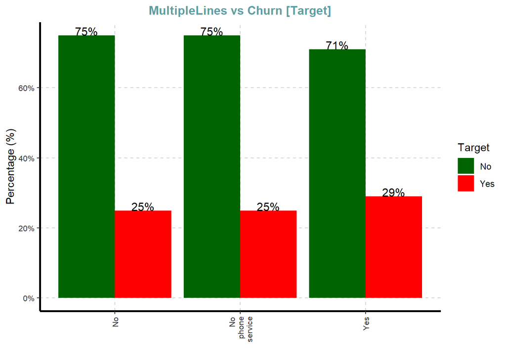

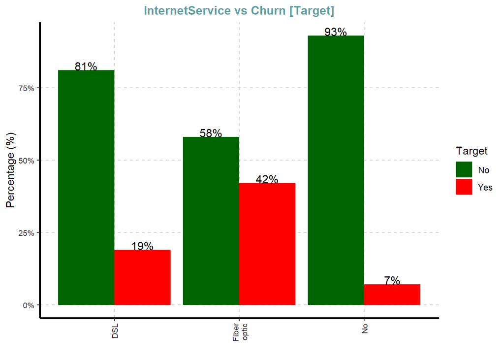

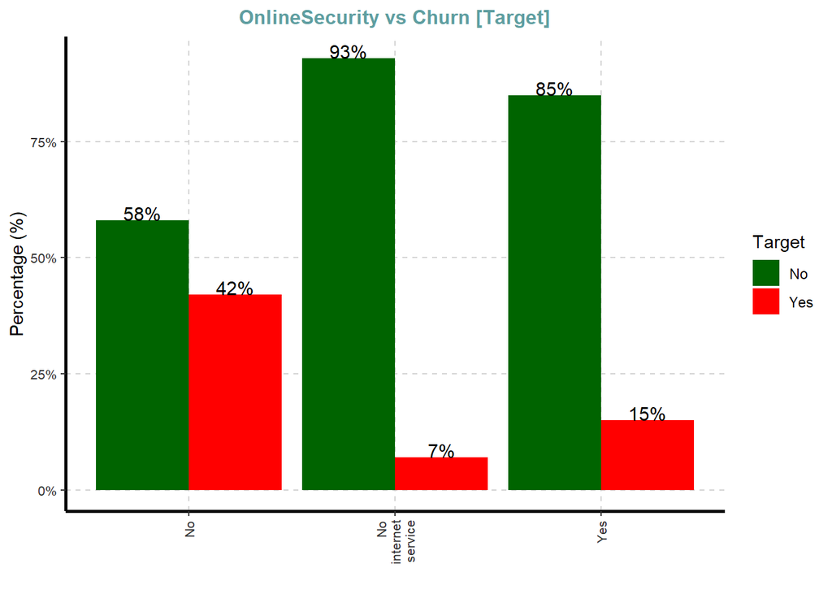

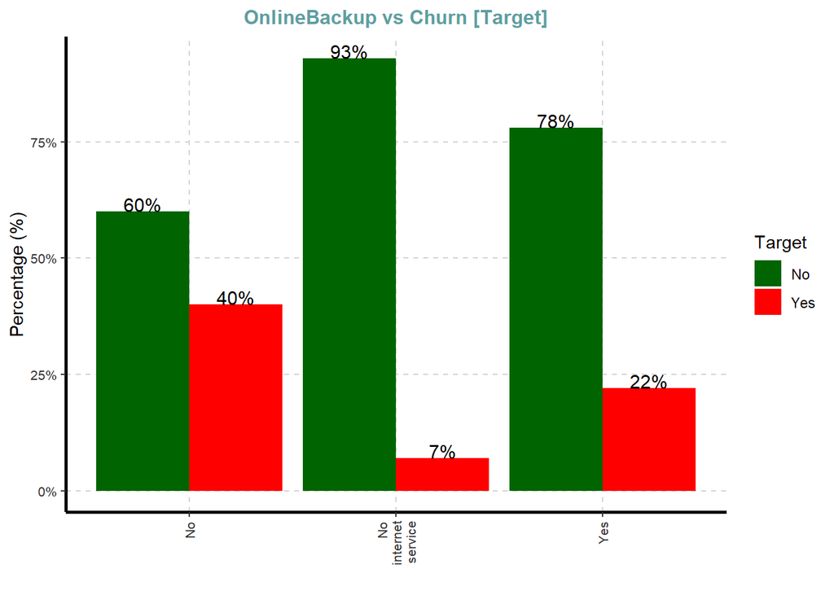

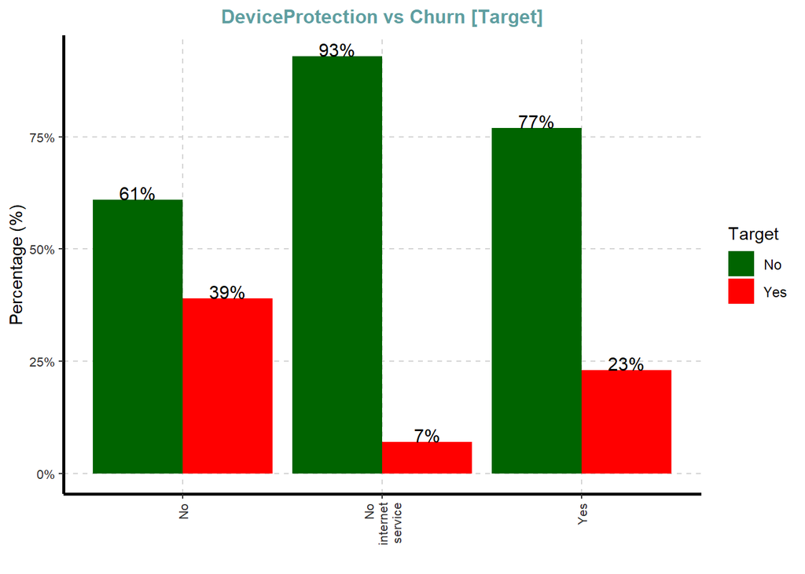

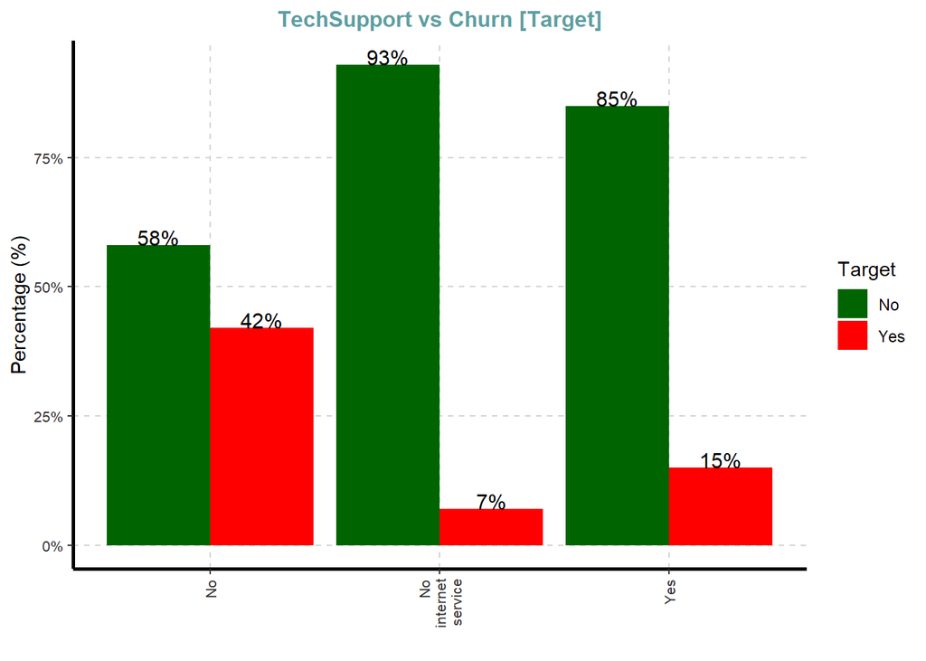

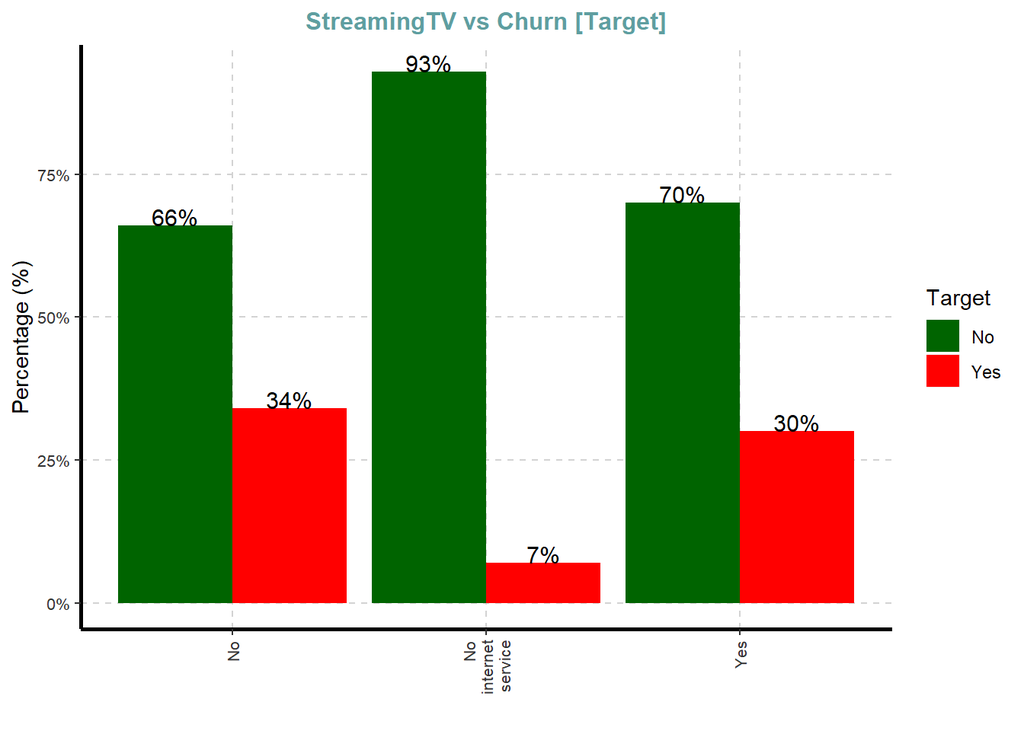

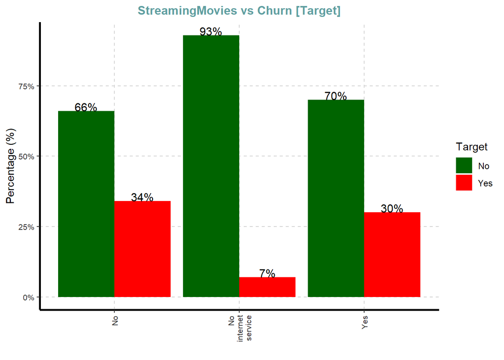

[6 more figures not shown]

```r
ExpCatViz(data,target="Churn", col = c("DarkGreen", "Red"), margin = 2)
```

## Another approach

```r
featurePlot(x = data[, c(2:5)],
            y = data$Churn,
            plot = "box",
            strip=strip.custom(par.strip.text=list(cex=.7)),
            scales = list(x = list(relation="free"),
                          y = list(relation="free")))
```

[output not shown]

# Modeling part

In this part I am going to build a model following these steps:

- split the data into train and test set
- create some models on the train set and evaluate them the test set
- evaluate the models and pick the best one

Remember what we are doing:

We would like to create an alorithm (a model) which tells us: given the features that we have in our data whether a person is going to churn or not. Or in other words, we would like to predict what is chance that a person is going to churn in the next month.

## Create train and test datasets

In this part I am splitting the data into train and test set.

Why? To be able to evaluate my model on unseen data. In this way, I hold out the test set while createing my model on the train set. With the help of this method I can make sure that my model is acting the similar way as on the training data. In more data science terms I can make sure that I chose model parameters as it is not overfiting (or underfitting) my data.

I will show you some examples what I mean under that.

```r
set.seed(314)
```

```r
#caret package
train_instances <- createDataPartition(data$Churn, p = 0.8, list = F)

train_instances[1:10]
```

```
##  [1]  1  3  4  5  6  7  9 10 11 12
```

```r
dataTrain <- data[train_instances, ]
dataTest <- data[-train_instances]
```

Original row count in the data

```r
print("Original row count in the data")
```

```
## [1] "Original row count in the data"
```

```r
nrow(data)
```

```
## [1] 7043
```

Train row count

```r
nrow(dataTrain)
```

```
## [1] 5636
```

Test row count

```r
nrow(dataTest)
```

```
## [1] 1407
```

Train + Test rows sum are equal original data rows

```r
nrow(data) == nrow(dataTrain) + nrow(dataTest)
```

```
## [1] TRUE
```

## Using the ‘caret’ package:

Now comes the important stage where you actually build the machine learning model.

To know what models caret supports, run the following:

```r
# See available algorithms in caret
modelnames <- paste(names(getModelInfo()), collapse=',  ')
modelnames
```

```
## [1] "ada,  AdaBag,  AdaBoost.M1,  adaboost,  amdai,  ANFIS,  avNNet,  awnb,  awtan,  bag,  bagEarth,  bagEarthGCV,  bagFDA,  bagFDAGCV,  bam,  bartMachine,  bayesglm,  binda,  blackboost,  blasso,  blassoAveraged,  bridge,  brnn,  BstLm,  bstSm,  bstTree,  C5.0,  C5.0Cost,  C5.0Rules,  C5.0Tree, …
```

Each of those is a machine learning algorithm caret supports.

Yes, it’s a huge list!

And if you want to know more details like the hyperparameters and if it can be used of regression or classification problem, then do a ‘modelLookup(algo)’.

```r
modelLookup(c('glmnet'))
```

|  | model | parameter | label | forReg | forClass | probModel |
| --- | --- | --- | --- | --- | --- | --- |
| 1 | glmnet | alpha | Mixing Percentage | TRUE | TRUE | TRUE |
| 2 | glmnet | lambda | Regularization Parameter | TRUE | TRUE | TRUE |

```r
modelLookup(c('knn'))
```

|  | model | parameter | label | forReg | forClass | probModel |
| --- | --- | --- | --- | --- | --- | --- |
| 1 | knn | k | #Neighbors | TRUE | TRUE | TRUE |

Once you have chosen an algorithm, building the model is fairly easy with caret.

```r
dataTrain[, churnNumeric:= NULL]
```

## Chaeck the data once more

```r
head(dataTrain)
```

| gender | SeniorCitizen | Partner | Dependents | tenure | PhoneService | MultipleLines | InternetService | OnlineSecurity | OnlineBackup | DeviceProtection | TechSupport | StreamingTV | StreamingMovies | Contract | PaperlessBilling | PaymentMethod | MonthlyCharges | TotalCharges | Churn | MonthlyChargesGroup |
| --- | --- | --- | --- | --- | --- | --- | --- | --- | --- | --- | --- | --- | --- | --- | --- | --- | --- | --- | --- | --- |
| Female | 0 | Yes | No | 1 | No | No phone service | DSL | No | Yes | No | No | No | No | Month-to-month | Yes | Electronic check | 29.85 | 29.85 | No | 2 |
| Male | 0 | No | No | 2 | Yes | No | DSL | Yes | Yes | No | No | No | No | Month-to-month | Yes | Mailed check | 53.85 | 108.15 | Yes | 3 |
| Male | 0 | No | No | 45 | No | No phone service | DSL | Yes | No | Yes | Yes | No | No | One year | No | Bank transfer (automatic) | 42.30 | 1840.75 | No | 2 |
| Female | 0 | No | No | 2 | Yes | No | Fiber optic | No | No | No | No | No | No | Month-to-month | Yes | Electronic check | 70.70 | 151.65 | Yes | 3 |
| Female | 0 | No | No | 8 | Yes | Yes | Fiber optic | No | No | Yes | No | Yes | Yes | Month-to-month | Yes | Electronic check | 99.65 | 820.50 | Yes | 4 |
| Male | 0 | No | Yes | 22 | Yes | Yes | Fiber optic | No | Yes | No | No | Yes | No | Month-to-month | Yes | Credit card (automatic) | 89.10 | 1949.40 | No | 4 |

## Set up Cross Validation

```r
train_control <- trainControl(method = "cv",
                              number = 10,
                              classProbs = TRUE,
                              summaryFunction = twoClassSummary,
                              verboseIter = FALSE, # no training log
                              allowParallel = TRUE # FALSE for reproducible results
                              )
```

## Model 1: Decision Tree

```r
rpartGrid <- expand.grid(cp=seq(0, 0.01, 0.001))
```

```r
decisonTreeModel <- train(Churn ~ .,
               data=dataTrain,
               trControl=train_control,
               method = "rpart",
               tuneGrid = rpartGrid,
               metric = "ROC")

decisonTreeSmall <- train(Churn ~ .,
               data=dataTrain,
               trControl=train_control,
               method = "rpart",
               tuneGrid = expand.grid(cp=seq(0.0075, 0.01, 0.001)),
               metric = "ROC")
```

```r
decisonTreeModel
```

```
## CART
##
## 5636 samples
##   20 predictor
##    2 classes: 'No', 'Yes'
##
## No pre-processing
## Resampling: Cross-Validated (10 fold)
## Summary of sample sizes: 5073, 5072, 5072, 5072, 5072, 5072, ...
## Resampling results across tuning parameters:
##
##   cp     ROC        Sens       Spec
##   0.000  0.8009527  0.8594203  0.5026622
##   0.001  0.7984773  0.8898551  0.4799642
##   0.002  0.7965485  0.8983092  0.4893602
##   0.003  0.7767514  0.9099034  0.4653244
##   0.004  0.7518102  0.9086957  0.4593289
##   0.005  0.7127692  0.9159420  0.4399329
##   0.006  0.7096186  0.9214976  0.4259060
##   0.007  0.7096186  0.9214976  0.4259060
##   0.008  0.7074542  0.9299517  0.4018031
##   0.009  0.7066922  0.9333333  0.3937494
##   0.010  0.7066922  0.9333333  0.3937494
##
## ROC was used to select the optimal model using the largest value.
## The final value used for the model was cp = 0.
```

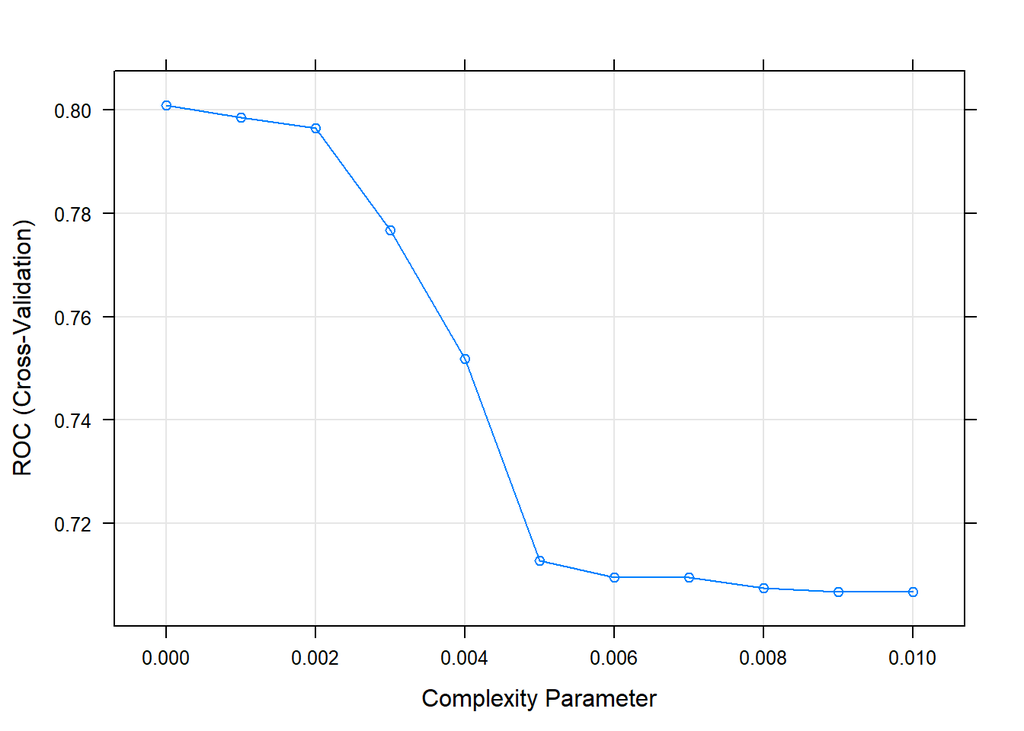

```r
plot(decisonTreeModel)
```

```r
#install.packages("rattle")
library(rattle)
```

[figure not shown]

```r
fancyRpartPlot(decisonTreeModel$finalModel)
```

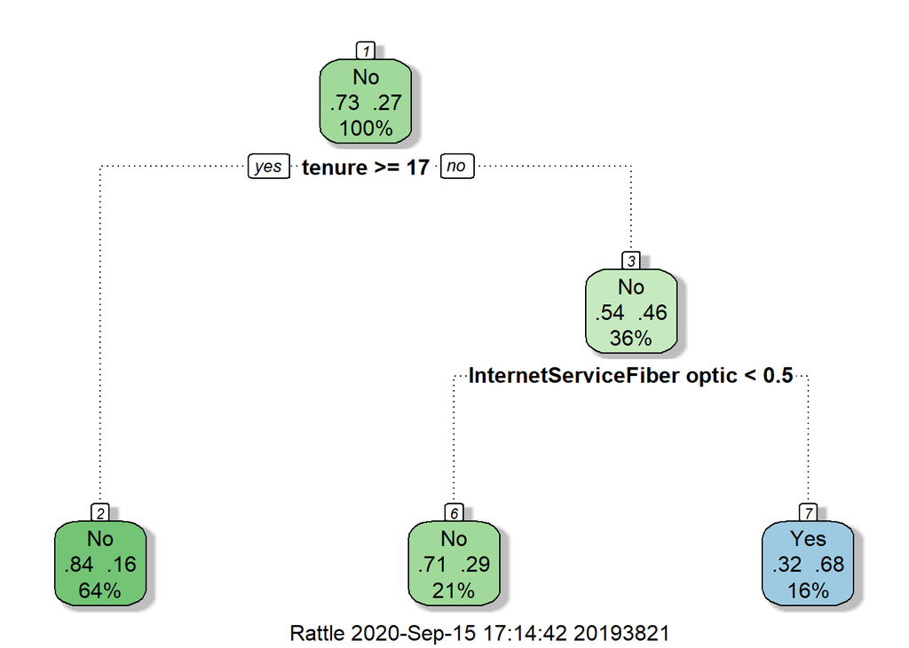

```r
fancyRpartPlot(decisonTreeSmall$finalModel)
```

## Model 2: ElasticNet - Lasso and Ridge models combined

- If alpha = 1 that is a Lasso regression
- If alpha = 0 that is a Ridge regression

Elasticnet combines both

```r
elasticGrid <- expand.grid(alpha=c(0, 0.05, 0.1, 0.3, 0.5, 0.6, 0.7, 0.8, 0.9,  1), lambda = c(0, 0.1, 0.25, 0.5, 0.75, 1))
elasticGrid
```

| alpha | lambda |
| --- | --- |
| 0.00 | 0.00 |
| 0.05 | 0.00 |
| 0.10 | 0.00 |
| 0.30 | 0.00 |
| 0.50 | 0.00 |
| 0.60 | 0.00 |
| 0.70 | 0.00 |
| 0.80 | 0.00 |
| 0.90 | 0.00 |
| 1.00 | 0.00 |

[output cut: 50 more lines]

```r
elasticNet <- train(Churn ~ .,
               data=dataTrain,
               trControl=train_control,
               method = "glmnet",
               tuneGrid = elasticGrid,
               metric = "ROC")
```

```r
elasticNet
```

```
## glmnet
##
## 5636 samples
##   20 predictor
##    2 classes: 'No', 'Yes'
##
## No pre-processing
## Resampling: Cross-Validated (10 fold)
## Summary of sample sizes: 5072, 5072, 5073, 5072, 5072, 5072, ...
## Resampling results across tuning parameters:
##
##   alpha  lambda  ROC        Sens       Spec
##   0.00   0.00    0.8399783  0.9043478  0.52205817
##   0.00   0.10    0.8367907  0.9268116  0.44781655
##   0.00   0.25    0.8338560  0.9528986  0.31882774
##   0.00   0.50    0.8306126  0.9845411  0.15039374
##   0.00   0.75    0.8284909  0.9990338  0.01402685
##   0.00   1.00    0.8269100  1.0000000  0.00000000
##   0.05   0.00    0.8425538  0.8968599  0.54543624
##   0.05   0.10    0.8367151  0.9301932  0.41973602
##   0.05   0.25    0.8342723  0.9717391  0.23259508
##   0.05   0.50    0.8319046  1.0000000  0.00000000
##   0.05   0.75    0.8299092  1.0000000  0.00000000
##   0.05   1.00    0.8281627  1.0000000  0.00000000
##   0.10   0.00    0.8425814  0.8971014  0.54543624
##   0.10   0.10    0.8364658  0.9381643  0.38766443
##   0.10   0.25    0.8343539  0.9888889  0.12768233
##   0.10   0.50    0.8314033  1.0000000  0.00000000
##   0.10   0.75    0.8256199  1.0000000  0.00000000
##   0.10   1.00    0.8224096  1.0000000  0.00000000
##   0.30   0.00    0.8424652  0.8968599  0.54476957
##   0.30   0.10    0.8352919  0.9649758  0.25464877
##   0.30   0.25    0.8253284  1.0000000  0.00000000
##   0.30   0.50    0.7424706  1.0000000  0.00000000
##   0.30   0.75    0.5000000  1.0000000  0.00000000
##   0.30   1.00    0.5000000  1.0000000  0.00000000
##   0.50   0.00    0.8424536  0.8966184  0.54610738
##   0.50   0.10    0.8303331  0.9908213  0.10762864
##   0.50   0.25    0.8018622  1.0000000  0.00000000
##   0.50   0.50    0.5000000  1.0000000  0.00000000
```

[output cut: 20 more lines]

```
##   0.90   0.00    0.8425551  0.8971014  0.54677405
##   0.90   0.10    0.8171261  1.0000000  0.00000000
##   0.90   0.25    0.5000000  1.0000000  0.00000000
##   0.90   0.50    0.5000000  1.0000000  0.00000000
##   0.90   0.75    0.5000000  1.0000000  0.00000000
##   0.90   1.00    0.5000000  1.0000000  0.00000000
##   1.00   0.00    0.8425486  0.8971014  0.54744072
##   1.00   0.10    0.8143398  1.0000000  0.00000000
##   1.00   0.25    0.5000000  1.0000000  0.00000000
##   1.00   0.50    0.5000000  1.0000000  0.00000000
##   1.00   0.75    0.5000000  1.0000000  0.00000000
##   1.00   1.00    0.5000000  1.0000000  0.00000000
##
## ROC was used to select the optimal model using the largest value.
## The final values used for the model were alpha = 0.1 and lambda = 0.
```

## Model 3: Random Forest

```r
length(colnames(dataTrain))
```

```
## [1] 21
```

```r
rfGrid <- expand.grid(mtry=c(3, 5, 10, 15, 20))
```

```r
rfGrid
```

| mtry |
| --- |
| 3 |
| 5 |
| 10 |
| 15 |
| 20 |

```r
randomForestModel <- train(Churn ~ .,
                           data = dataTrain,
                           trControl = train_control,
                           method = "rf",
                           tuneGrid = rfGrid,
                           metric = "ROC")
```

```r
randomForestModel
```

```
## Random Forest
##
## 5636 samples
##   20 predictor
##    2 classes: 'No', 'Yes'
##
## No pre-processing
## Resampling: Cross-Validated (10 fold)
## Summary of sample sizes: 5072, 5072, 5073, 5073, 5072, 5073, ...
## Resampling results across tuning parameters:
##
##   mtry  ROC        Sens       Spec
##    3    0.8332241  0.9140097  0.4759284
##    5    0.8315360  0.9002415  0.5093557
##   10    0.8246677  0.9019324  0.4945727
##   15    0.8205267  0.8956522  0.4872438
##   20    0.8184068  0.8966184  0.4879060
##
## ROC was used to select the optimal model using the largest value.
## The final value used for the model was mtry = 3.
```

```r
rfGrid <- expand.grid(mtry=c(1:6))
```

```r
rfGrid
```

| mtry |
| --- |
| 1 |
| 2 |
| 3 |
| 4 |
| 5 |
| 6 |

```r
randomForestModel <- train(Churn ~ .,
                           data = dataTrain,
                           trControl = train_control,
                           method = "rf",
                           tuneGrid = rfGrid,
                           metric = "ROC")
```

```r
randomForestModel
```

```
## Random Forest
##
## 5636 samples
##   20 predictor
##    2 classes: 'No', 'Yes'
##
## No pre-processing
## Resampling: Cross-Validated (10 fold)
## Summary of sample sizes: 5073, 5073, 5072, 5072, 5072, 5072, ...
## Resampling results across tuning parameters:
##
##   mtry  ROC        Sens       Spec
##   1     0.8270625  1.0000000  0.004689038
##   2     0.8297335  0.9461353  0.364322148
##   3     0.8327441  0.9154589  0.480644295
##   4     0.8318848  0.9028986  0.504053691
##   5     0.8304149  0.9016908  0.502040268
##   6     0.8287531  0.9002415  0.504062640
##
## ROC was used to select the optimal model using the largest value.
## The final value used for the model was mtry = 3.
```

```r
varImp(randomForestModel)
```

```
## rf variable importance
##
##   only 20 most important variables shown (out of 31)
##
##                               Overall
## tenure                        100.000
## TotalCharges                   90.322
## MonthlyCharges                 65.256
## InternetServiceFiber optic     34.007
## PaymentMethodElectronic check  29.459
## ContractTwo year               28.932
## TechSupportYes                 17.180
## ContractOne year               16.404
## OnlineSecurityYes              16.271
## MonthlyChargesGroup            16.270
## PaperlessBillingYes            12.091
## OnlineBackupYes                10.397
## PartnerYes                      8.025
## DeviceProtectionYes             7.635
## genderMale                      7.489
## SeniorCitizen                   7.203
## DependentsYes                   6.749
## MultipleLinesYes                6.578
## StreamingMoviesYes              5.520
## StreamingTVYes                  5.234
```

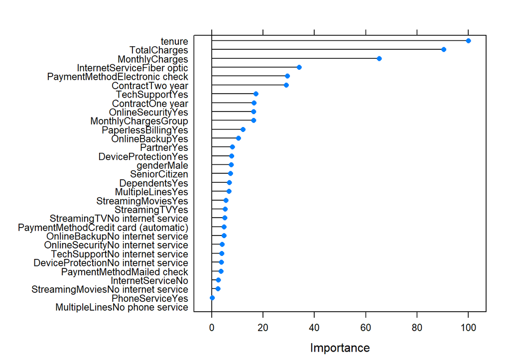

```r
plot(varImp(randomForestModel))
```

# Model 4: xgboost

```r
# Tested the above setting in local machine
xgbGrid <- expand.grid(nrounds = c(1000),
                        max_depth = c(3, 4),
                        eta = c(0.01),
                        gamma = c(0.01, 0.05),
                        colsample_bytree = 0.75,
                        min_child_weight = 0,
                        subsample = 0.5)

#nrounds: Number of trees, default: 100
#max_depth: Maximum tree depth, default: 6
#eta: Learning rate, default: 0.3
#gamma: Used for tuning of Regularization, default: 0
#colsample_bytree: Column sampling, default: 1
#min_child_weight: Minimum leaf weight, default: 1
#subsample: Row sampling, default: 1

xgboostModel <- train(Churn ~ .,
                      data = dataTrain,
                      trControl = train_control,
                      method = "xgbTree",
                      tuneGrid = xgbGrid,
                      metric = "ROC",
                      verbose = TRUE)
```

```r
xgboostModel
```

```
## eXtreme Gradient Boosting
##
## 5636 samples
##   20 predictor
##    2 classes: 'No', 'Yes'
##
## No pre-processing
## Resampling: Cross-Validated (10 fold)
## Summary of sample sizes: 5073, 5072, 5072, 5072, 5072, 5072, ...
## Resampling results across tuning parameters:
##
##   max_depth  gamma  ROC        Sens       Spec
##   3          0.01   0.8472795  0.9033816  0.5260805
##   3          0.05   0.8471882  0.9031401  0.5267427
##   4          0.01   0.8443638  0.8985507  0.5213647
##   4          0.05   0.8448025  0.9007246  0.5220626
##
## Tuning parameter 'nrounds' was held constant at a value of 1000
##
## Tuning parameter 'min_child_weight' was held constant at a value of 0
##
## Tuning parameter 'subsample' was held constant at a value of 0.5
## ROC was used to select the optimal model using the largest value.
## The final values used for the model were nrounds = 1000, max_depth = 3, eta
##  = 0.01, gamma = 0.01, colsample_bytree = 0.75, min_child_weight = 0
##  and subsample = 0.5.
```

# Prediction on the train set

Now that we have our models we can see how they performe on the train set.

BE CAREFUL: this is on your train set on seen data. It still might be that someting went wrong. (The chance is low since we did cross validation but still). If we want to evaluate our model we should do that in the test set, what we are going to do next.

```r
dataTrain[, dectree:=predict(decisonTreeModel, newdata = dataTrain)]
dataTrain[, dectree_prob:=predict(decisonTreeModel, newdata = dataTrain, type = "prob")[, "Yes"]]
dataTrain[, dectreeNumeric:= ifelse(dectree_prob > 0.5, 1, 0)]

dataTrain[, elastic:=predict(elasticNet, newdata = dataTrain)]
dataTrain[, elastic_prob:=predict(elasticNet, newdata = dataTrain, type = "prob")[, "Yes"]]
dataTrain[, elastic_numeric:= ifelse(elastic_prob > 0.5, 1, 0)]

dataTrain[, rf:= predict(randomForestModel, newdata = dataTrain)]
dataTrain[, rf_prob:=predict(randomForestModel, newdata = dataTrain, type = "prob")[, "Yes"]]
dataTrain[, rfNumeric:= ifelse(rf_prob > 0.5, 1, 0)]

dataTrain[, xgboost:= predict(xgboostModel, newdata = dataTrain)]
dataTrain[, xg_prob:=predict(xgboostModel, newdata = dataTrain, type = "prob")[, "Yes"]]
dataTrain[, xgNumeric:= ifelse(xg_prob > 0.5, 1, 0)]
```

```r
head(dataTrain)
```

| gender | SeniorCitizen | Partner | Dependents | tenure | PhoneService | MultipleLines | InternetService | OnlineSecurity | OnlineBackup | DeviceProtection | TechSupport | StreamingTV | StreamingMovies | Contract | PaperlessBilling | PaymentMethod | MonthlyCharges | TotalCharges | Churn | MonthlyChargesGroup | dectree | dectree_prob | dectreeNumeric | elastic | elastic_prob | elastic_numeric | rf | rf_prob | rfNumeric | … |
| --- | --- | --- | --- | --- | --- | --- | --- | --- | --- | --- | --- | --- | --- | --- | --- | --- | --- | --- | --- | --- | --- | --- | --- | --- | --- | --- | --- | --- | --- | --- |
| Female | 0 | Yes | No | 1 | No | No phone service | DSL | No | Yes | No | No | No | No | Month-to-month | Yes | Electronic check | 29.85 | 29.85 | No | 2 | No | 0.28571429 | 0 | Yes | 0.61861443 | 1 | No | 0.474 | 0 | … |
| Male | 0 | No | No | 2 | Yes | No | DSL | Yes | Yes | No | No | No | No | Month-to-month | Yes | Mailed check | 53.85 | 108.15 | Yes | 3 | Yes | 0.83333333 | 1 | No | 0.28577413 | 0 | No | 0.446 | 0 | … |
| Male | 0 | No | No | 45 | No | No phone service | DSL | Yes | No | Yes | Yes | No | No | One year | No | Bank transfer (automatic) | 42.30 | 1840.75 | No | 2 | No | 0.06818182 | 0 | No | 0.02858435 | 0 | No | 0.006 | 0 | … |
| Female | 0 | No | No | 2 | Yes | No | Fiber optic | No | No | No | No | No | No | Month-to-month | Yes | Electronic check | 70.70 | 151.65 | Yes | 3 | Yes | 0.72000000 | 1 | Yes | 0.69751139 | 1 | Yes | 0.858 | 1 | … |
| Female | 0 | No | No | 8 | Yes | Yes | Fiber optic | No | No | Yes | No | Yes | Yes | Month-to-month | Yes | Electronic check | 99.65 | 820.50 | Yes | 4 | Yes | 0.93877551 | 1 | Yes | 0.77035629 | 1 | Yes | 0.904 | 1 | … |
| Male | 0 | No | Yes | 22 | Yes | Yes | Fiber optic | No | Yes | No | No | Yes | No | Month-to-month | Yes | Credit card (automatic) | 89.10 | 1949.40 | No | 4 | No | 0.40000000 | 0 | No | 0.47505572 | 0 | No | 0.206 | 0 | … |

Get the accuracy of each model on the train set:

```r
mean(dataTrain$Churn == dataTrain$dectree)
```

```
## [1] 0.860362
```

```r
mean(dataTrain$Churn == dataTrain$elastic)
```

```
## [1] 0.805181
```

```r
mean(dataTrain$Churn == dataTrain$rf)
```

```
## [1] 0.8548616
```

```r
mean(dataTrain$Churn == dataTrain$xgboost)
```

```
## [1] 0.8206175
```

# Predict on the test set

```r
dataTest[, dectree:=predict(decisonTreeModel, newdata = dataTest)]
dataTest[, dectree_prob:=predict(decisonTreeModel, newdata = dataTest, type = "prob")[, "Yes"]]
dataTest[, dectreeNumeric:= ifelse(dectree_prob > 0.5, 1, 0)]

dataTest[, elastic:=predict(elasticNet, newdata = dataTest)]
dataTest[, elastic_prob:=predict(elasticNet, newdata = dataTest, type = "prob")[, "Yes"]]
dataTest[, elasticNumeric:= ifelse(elastic_prob > 0.5, 1, 0)]

dataTest[, rf:= predict(randomForestModel, newdata = dataTest)]
dataTest[, rf_prob:=predict(randomForestModel, newdata = dataTest, type = "prob")[, "Yes"]]
dataTest[, rfNumeric:= ifelse(rf_prob > 0.5, 1, 0)]

dataTest[, xgboost:= predict(xgboostModel, newdata = dataTest)]
dataTest[, xg_prob:=predict(xgboostModel, newdata = dataTest, type = "prob")[, "Yes"]]
dataTest[, xgNumeric:= ifelse(xg_prob > 0.5, 1, 0)]
```

```r
head(dataTest)
```

| gender | SeniorCitizen | Partner | Dependents | tenure | PhoneService | MultipleLines | InternetService | OnlineSecurity | OnlineBackup | DeviceProtection | TechSupport | StreamingTV | StreamingMovies | Contract | PaperlessBilling | PaymentMethod | MonthlyCharges | TotalCharges | Churn | churnNumeric | MonthlyChargesGroup | dectree | dectree_prob | dectreeNumeric | elastic | elastic_prob | elasticNumeric | rf | rf_prob | … |
| --- | --- | --- | --- | --- | --- | --- | --- | --- | --- | --- | --- | --- | --- | --- | --- | --- | --- | --- | --- | --- | --- | --- | --- | --- | --- | --- | --- | --- | --- | --- |
| Male | 0 | No | No | 34 | Yes | No | DSL | Yes | No | Yes | No | No | No | One year | No | Mailed check | 56.95 | 1889.50 | No | 0 | 3 | No | 0.08050847 | 0 | No | 0.04144158 | 0 | No | 0.014 | … |
| Female | 0 | No | No | 10 | No | No phone service | DSL | Yes | No | No | No | No | No | Month-to-month | No | Mailed check | 29.75 | 301.90 | No | 0 | 2 | No | 0.14705882 | 0 | No | 0.31825979 | 0 | No | 0.106 | … |
| Male | 0 | Yes | Yes | 1 | No | No phone service | DSL | No | Yes | No | No | No | No | Month-to-month | No | Electronic check | 30.20 | 30.20 | Yes | 1 | 2 | Yes | 0.54545455 | 1 | No | 0.48916200 | 0 | No | 0.430 | … |
| Female | 0 | No | Yes | 17 | Yes | No | DSL | No | No | No | No | Yes | Yes | Month-to-month | Yes | Mailed check | 64.70 | 1093.10 | Yes | 1 | 3 | No | 0.09756098 | 0 | No | 0.37431548 | 0 | No | 0.084 | … |
| Female | 0 | Yes | Yes | 27 | Yes | No | DSL | Yes | Yes | Yes | Yes | No | No | One year | No | Mailed check | 66.15 | 1874.45 | No | 0 | 3 | No | 0.08050847 | 0 | No | 0.03315050 | 0 | No | 0.044 | … |
| Male | 0 | No | No | 5 | Yes | No | Fiber optic | No | No | No | No | No | No | Month-to-month | Yes | Electronic check | 69.70 | 316.90 | Yes | 1 | 3 | Yes | 0.72000000 | 1 | Yes | 0.65896686 | 1 | Yes | 0.754 | … |

# Evaluate and selecting the best model using the test set:

## Calculate ROC on the test set:

Install ‘PRROC’ package that calculates the ROC curve (and the AUC)

```r
#install.packages("PRROC")
library(PRROC)
```

### ROC DecisionTree:

```r
roc.curve(scores.class0 = dataTest$dectree_prob, weights.class0=dataTest$churnNumeric)
```

```
##
##   ROC curve
##
##     Area under curve:
##      0.8232715
##
##     Curve not computed ( can be done by using curve=TRUE )
```

### ROC ElasticNet:

```r
roc.curve(scores.class0 = dataTest$elastic_prob, weights.class0=dataTest$churnNumeric)
```

```
##
##   ROC curve
##
##     Area under curve:
##      0.8552123
##
##     Curve not computed ( can be done by using curve=TRUE )
```

### ROC RandomForest:

```r
roc.curve(scores.class0 = dataTest$rf_prob, weights.class0=dataTest$churnNumeric)
```

```
##
##   ROC curve
##
##     Area under curve:
##      0.8379468
##
##     Curve not computed ( can be done by using curve=TRUE )
```

### ROC xgBoost

```r
roc.curve(scores.class0 = dataTest$xg_prob, weights.class0=dataTest$churnNumeric)
```

```
##
##   ROC curve
##
##     Area under curve:
##      0.856287
##
##     Curve not computed ( can be done by using curve=TRUE )
```

## Calculate Confusion Matrix:

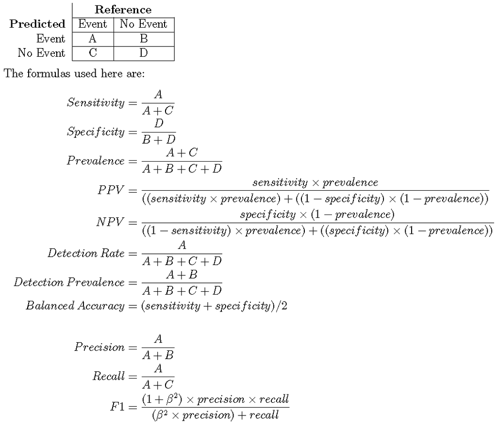

## CM for DecisionTree:

```r
confusionMatrix(as.factor(dataTest$dectreeNumeric), as.factor(dataTest$churnNumeric), #mode = "prec_recall"
                positive = "1",

                )
```

```
## Confusion Matrix and Statistics
##
##           Reference
## Prediction   0   1
##          0 884 169
##          1 150 204
##
##                Accuracy : 0.7733
##                  95% CI : (0.7505, 0.7949)
##     No Information Rate : 0.7349
##     P-Value [Acc > NIR] : 0.0005191
##
##                   Kappa : 0.4085
##
##  Mcnemar's Test P-Value : 0.3135474
##
##             Sensitivity : 0.5469
##             Specificity : 0.8549
##          Pos Pred Value : 0.5763
##          Neg Pred Value : 0.8395
##              Prevalence : 0.2651
##          Detection Rate : 0.1450
##    Detection Prevalence : 0.2516
##       Balanced Accuracy : 0.7009
##
##        'Positive' Class : 1
##
```

## CM for ElasticNet:

```r
confusionMatrix(as.factor(dataTest$elasticNumeric), as.factor(dataTest$churnNumeric), #mode = "prec_recall"
                positive = "1",

                )
```

```
## Confusion Matrix and Statistics
##
##           Reference
## Prediction   0   1
##          0 939 175
##          1  95 198
##
##                Accuracy : 0.8081
##                  95% CI : (0.7865, 0.8284)
##     No Information Rate : 0.7349
##     P-Value [Acc > NIR] : 7.824e-11
##
##                   Kappa : 0.4713
##
##  Mcnemar's Test P-Value : 1.526e-06
##
##             Sensitivity : 0.5308
##             Specificity : 0.9081
##          Pos Pred Value : 0.6758
##          Neg Pred Value : 0.8429
##              Prevalence : 0.2651
##          Detection Rate : 0.1407
##    Detection Prevalence : 0.2082
##       Balanced Accuracy : 0.7195
##
##        'Positive' Class : 1
##
```

## CM for RandomForest:

```r
confusionMatrix(as.factor(dataTest$rfNumeric), as.factor(dataTest$churnNumeric), #mode = "prec_recall",
                positive = "1")
```

```
## Confusion Matrix and Statistics
##
##           Reference
## Prediction   0   1
##          0 952 203
##          1  82 170
##
##                Accuracy : 0.7974
##                  95% CI : (0.7755, 0.8182)
##     No Information Rate : 0.7349
##     P-Value [Acc > NIR] : 2.798e-08
##
##                   Kappa : 0.42
##
##  Mcnemar's Test P-Value : 1.176e-12
##
##             Sensitivity : 0.4558
##             Specificity : 0.9207
##          Pos Pred Value : 0.6746
##          Neg Pred Value : 0.8242
##              Prevalence : 0.2651
##          Detection Rate : 0.1208
##    Detection Prevalence : 0.1791
##       Balanced Accuracy : 0.6882
##
##        'Positive' Class : 1
##
```

## CM for xgBoost:

```r
confusionMatrix(as.factor(dataTest$xgNumeric), as.factor(dataTest$churnNumeric), #mode = "prec_recall",
                positive = "1")
```

```
## Confusion Matrix and Statistics
##
##           Reference
## Prediction   0   1
##          0 944 180
##          1  90 193
##
##                Accuracy : 0.8081
##                  95% CI : (0.7865, 0.8284)
##     No Information Rate : 0.7349
##     P-Value [Acc > NIR] : 7.824e-11
##
##                   Kappa : 0.4664
##
##  Mcnemar's Test P-Value : 6.082e-08
##
##             Sensitivity : 0.5174
##             Specificity : 0.9130
##          Pos Pred Value : 0.6820
##          Neg Pred Value : 0.8399
##              Prevalence : 0.2651
##          Detection Rate : 0.1372
##    Detection Prevalence : 0.2011
##       Balanced Accuracy : 0.7152
##
##        'Positive' Class : 1
##
```

## Calibration Curve

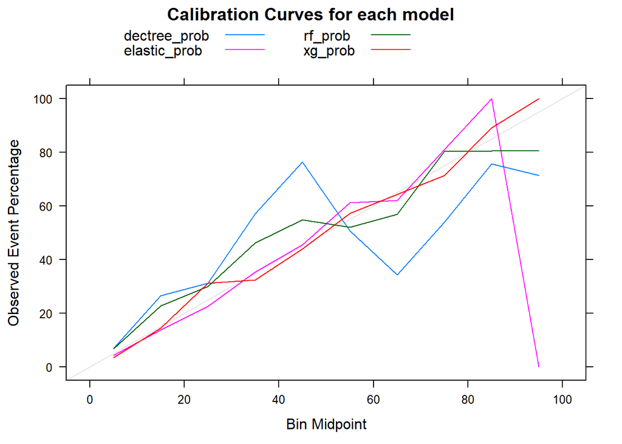

```r
cal_obj <- calibration(factor(churnNumeric, levels = c("1", "0")) ~ dectree_prob + elastic_prob + rf_prob + xg_prob,
                       data = dataTest,
                       cuts = 10)

plot(cal_obj,
     type = "l",
     auto.key = list(columns = 3,
                     lines = TRUE,
                     points = FALSE),
     main = "Calibration Curves for each model")
```